# Summarize and Explore the Data

R package that automates most of exploratory analyses tasks in modeling

Dayananda Ubrangala, Kiran R, Ravi Prasad Kondapalli, Sayan Putatunda

2024-01-30

## 1. Introduction

The document introduces the **SmartEDA** package and how it can help you to build exploratory data analysis.

**SmartEDA** includes multiple custom functions to perform initial exploratory analysis on any input data describing the structure and the relationships present in the data. The generated output can be obtained in both summary and graphical form. The graphical form or charts can also be exported as reports.

```
सर्वस्य लोचनं शास्त्रं
Science is the only eye

अनेकसंशयोच्छेदि, परोक्षार्थस्य दर्शक|
सर्वस्य लोचनं शास्त्रं, यस्य नास्त्यन्ध एव सः ||

It blasts many doubts, foresees what is not obvious |
Science is the eye of everyone, one who hasnt got it, is like a blind ||
```

**SmartEDA** package helps you to construct a good base of data understanding. The capabilities and functionalities are listed below

1. **SmartEDA** package will make you capable of applying different types of EDA without having to
   - remember the different R package names
   - write lengthy R scripts
   - manual effort to prepare the EDA report
2. No need to categorize the variables into Character, Numeric, Factor etc. SmartEDA functions automatically categorize all the features into the right data type (Character, Numeric, Factor etc.) based on the input data.
3. ggplot2 functions are used for graphical presentation of data
4. Rmarkdown and knitr functions were used for build HTML reports

To summarize, SmartEDA package helps in getting the complete exploratory data analysis just by running the function instead of writing lengthy r code.

### Journal of Open Source Software Article

An article describing SmartEDA package for exploratory data analysis approach has been published in [arxiv](https://arxiv.org/pdf/1903.04754.pdf) and Journal of Open Source Software [JOSS](https://joss.theoj.org/papers/10.21105/joss.01509). Please cite the paper if you use SmartEDA in your work!

## 2. Data

In this vignette, we will be using a simulated data set containing sales of child car seats at 400 different stores.

Data Source [ISLR package](https://www.rdocumentation.org/packages/ISLR/versions/1.2/topics/Carseats).

Install the package “ISLR” to get the example data set.

```r
#install.packages("ISLR")
library("ISLR")
#install.packages("SmartEDA")
library("SmartEDA")
## Load sample dataset from ISLR pacakge
Carseats= ISLR::Carseats
```

### 2.1 Overview of the data

Understanding the dimensions of the dataset, variable names, overall missing summary and data types of each variables

```r
# Overview of the data - Type = 1
ExpData(data=Carseats,type=1)

# Structure of the data - Type = 2
ExpData(data=Carseats,type=2)
```

- Overview of the data

  | Descriptions | Value |
  | --- | --- |
  | Sample size (nrow) | 400 |
  | No. of variables (ncol) | 11 |
  | No. of numeric/interger variables | 8 |
  | No. of factor variables | 3 |
  | No. of text variables | 0 |
  | No. of logical variables | 0 |
  | No. of identifier variables | 0 |
  | No. of date variables | 0 |
  | No. of zero variance variables (uniform) | 0 |
  | %. of variables having complete cases | 100% (11) |
  | %. of variables having >0% and <50% missing cases | 0% (0) |
  | %. of variables having >=50% and <90% missing cases | 0% (0) |
  | %. of variables having >=90% missing cases | 0% (0) |

- Structure of the data

| Index | Variable_Name | Variable_Type | Sample_n | Missing_Count | Per_of_Missing | No_of_distinct_values |
| --- | --- | --- | --- | --- | --- | --- |
| 1 | Sales | numeric | 400 | 0 | 0 | 336 |
| 2 | CompPrice | numeric | 400 | 0 | 0 | 73 |
| 3 | Income | numeric | 400 | 0 | 0 | 98 |
| 4 | Advertising | numeric | 400 | 0 | 0 | 28 |
| 5 | Population | numeric | 400 | 0 | 0 | 275 |
| 6 | Price | numeric | 400 | 0 | 0 | 101 |
| 7 | ShelveLoc | factor | 400 | 0 | 0 | 3 |
| 8 | Age | numeric | 400 | 0 | 0 | 56 |
| 9 | Education | numeric | 400 | 0 | 0 | 9 |
| 10 | Urban | factor | 400 | 0 | 0 | 2 |
| 11 | US | factor | 400 | 0 | 0 | 2 |

### 2.2 Add summary statistics into Metadata ouput

- Metadata Information with additional statistics like mean, median and variance

```r
# Metadata Information with additional statistics like mean, median and variance
ExpData(data=Carseats,type=2, fun = c("mean", "median", "var"))
```

| Index | Variable_Name | Variable_Type | Sample_n | Missing_Count | Per_of_Missing | No_of_distinct_values | mean | median | var |
| --- | --- | --- | --- | --- | --- | --- | --- | --- | --- |
| 1 | Sales | numeric | 400 | 0 | 0 | 336 | 7.50 | 7.49 | 7.98 |
| 2 | CompPrice | numeric | 400 | 0 | 0 | 73 | 124.97 | 125.00 | 235.15 |
| 3 | Income | numeric | 400 | 0 | 0 | 98 | 68.66 | 69.00 | 783.22 |
| 4 | Advertising | numeric | 400 | 0 | 0 | 28 | 6.64 | 5.00 | 44.23 |
| 5 | Population | numeric | 400 | 0 | 0 | 275 | 264.84 | 272.00 | 21719.81 |
| 6 | Price | numeric | 400 | 0 | 0 | 101 | 115.80 | 117.00 | 560.58 |
| 7 | ShelveLoc | factor | 400 | 0 | 0 | 3 | NA | NA | NA |
| 8 | Age | numeric | 400 | 0 | 0 | 56 | 53.32 | 54.50 | 262.45 |
| 9 | Education | numeric | 400 | 0 | 0 | 9 | 13.90 | 14.00 | 6.87 |
| 10 | Urban | factor | 400 | 0 | 0 | 2 | NA | NA | NA |
| 11 | US | factor | 400 | 0 | 0 | 2 | NA | NA | NA |

- Adding custom function like 10th percentile or 90th percentile

```r
# Derive Quantile
quantile_10 = function(x){
  quantile_10 = quantile(x, na.rm = TRUE, 0.1)
}

quantile_90 = function(x){
  quantile_90 = quantile(x, na.rm = TRUE, 0.9)
}

output_e1 <- ExpData(data=Carseats, type=2, fun=c("quantile_10", "quantile_90"))
```

| Index | Variable_Name | Variable_Type | Sample_n | Missing_Count | Per_of_Missing | No_of_distinct_values | quantile_10 | quantile_90 |
| --- | --- | --- | --- | --- | --- | --- | --- | --- |
| 1 | Sales | numeric | 400 | 0 | 0 | 336 | 4.12 | 11.3 |
| 2 | CompPrice | numeric | 400 | 0 | 0 | 73 | 106.00 | 145.0 |
| 3 | Income | numeric | 400 | 0 | 0 | 98 | 30.00 | 107.0 |
| 4 | Advertising | numeric | 400 | 0 | 0 | 28 | 0.00 | 16.0 |
| 5 | Population | numeric | 400 | 0 | 0 | 275 | 58.90 | 467.0 |
| 6 | Price | numeric | 400 | 0 | 0 | 101 | 87.00 | 146.0 |
| 7 | ShelveLoc | factor | 400 | 0 | 0 | 3 | NA | NA |
| 8 | Age | numeric | 400 | 0 | 0 | 56 | 30.00 | 76.0 |
| 9 | Education | numeric | 400 | 0 | 0 | 9 | 10.00 | 17.1 |
| 10 | Urban | factor | 400 | 0 | 0 | 2 | NA | NA |
| 11 | US | factor | 400 | 0 | 0 | 2 | NA | NA |

## 3. Exploratory data analysis (EDA)

This function shows the EDA output for 3 different cases

1. **Target variable is not defined**
2. **Target variable is continuous**
3. **Target variable is categorical**

### 3.1 Example for case 1: Target variable is not defined

#### 3.1.1 Summary of numerical variables

Summary of all numerical variables

```r
ExpNumStat(Carseats,by="A",gp=NULL,Qnt=seq(0,1,0.1),MesofShape=2,Outlier=TRUE,round=2,Nlim=10)
```

| Vname | Group | TN | nNeg | nZero | nPos | NegInf | PosInf | NA_Value | Per_of_Missing | sum | min | max | mean | median | SD | CV | IQR | Skewness | Kurtosis | 0% | 10% | 20% | 30% | 40% | 50% | 60% | 70% | 80% | 90% | … |
| --- | --- | --- | --- | --- | --- | --- | --- | --- | --- | --- | --- | --- | --- | --- | --- | --- | --- | --- | --- | --- | --- | --- | --- | --- | --- | --- | --- | --- | --- | --- |
| Advertising | All | 400 | 0 | 144 | 256 | 0 | 0 | 0 | 0 | 2654.00 | 0 | 29.00 | 6.64 | 5.00 | 6.65 | 1.00 | 12.00 | 0.64 | -0.55 | 0 | 0.00 | 0.00 | 0.00 | 2.00 | 5.00 | 8.40 | 11.00 | 13.00 | 16.0 | … |
| Age | All | 400 | 0 | 0 | 400 | 0 | 0 | 0 | 0 | 21329.00 | 25 | 80.00 | 53.32 | 54.50 | 16.20 | 0.30 | 26.25 | -0.08 | -1.14 | 25 | 30.00 | 36.00 | 43.00 | 48.60 | 54.50 | 60.00 | 64.00 | 70.00 | 76.0 | … |
| CompPrice | All | 400 | 0 | 0 | 400 | 0 | 0 | 0 | 0 | 49990.00 | 77 | 175.00 | 124.97 | 125.00 | 15.33 | 0.12 | 20.00 | -0.04 | 0.03 | 77 | 106.00 | 112.80 | 117.00 | 121.00 | 125.00 | 130.00 | 133.00 | 137.20 | 145.0 | … |
| Education | All | 400 | 0 | 0 | 400 | 0 | 0 | 0 | 0 | 5560.00 | 10 | 18.00 | 13.90 | 14.00 | 2.62 | 0.19 | 4.00 | 0.04 | -1.30 | 10 | 10.00 | 11.00 | 12.00 | 13.00 | 14.00 | 15.00 | 16.00 | 17.00 | 17.1 | … |
| Income | All | 400 | 0 | 0 | 400 | 0 | 0 | 0 | 0 | 27463.00 | 21 | 120.00 | 68.66 | 69.00 | 27.99 | 0.41 | 48.25 | 0.05 | -1.09 | 21 | 30.00 | 39.00 | 48.00 | 62.00 | 69.00 | 77.00 | 84.60 | 96.20 | 107.0 | … |
| Population | All | 400 | 0 | 0 | 400 | 0 | 0 | 0 | 0 | 105936.00 | 10 | 509.00 | 264.84 | 272.00 | 147.38 | 0.56 | 259.50 | -0.05 | -1.20 | 10 | 58.90 | 110.40 | 160.00 | 218.60 | 272.00 | 317.80 | 366.00 | 412.20 | 467.0 | … |
| Price | All | 400 | 0 | 0 | 400 | 0 | 0 | 0 | 0 | 46318.00 | 24 | 191.00 | 115.80 | 117.00 | 23.68 | 0.20 | 31.00 | -0.12 | 0.43 | 24 | 87.00 | 96.80 | 104.00 | 110.00 | 117.00 | 122.00 | 128.30 | 134.00 | 146.0 | … |
| Sales | All | 400 | 0 | 1 | 399 | 0 | 0 | 0 | 0 | 2998.53 | 0 | 16.27 | 7.50 | 7.49 | 2.82 | 0.38 | 3.93 | 0.18 | -0.10 | 0 | 4.12 | 5.07 | 5.87 | 6.61 | 7.49 | 8.08 | 8.82 | 9.76 | 11.3 | … |

##### Compute Weighted Summary Statistics for numerical variable

```r
carseat = ISLR::Carseats
## Compute random weight
carseat$wt = stats::runif( nrow(carseat), 0.5, 1.5 )
wt_summary = ExpNumStat(carseat,by="A",gp=NULL,round=2,Nlim=10, weight = "wt")
wt_summary[,c("Vname","TN","W_count","mean", "W_Mean", "SD","W_Sd")]
```

```
##         Vname  TN W_count   mean W_Mean     SD   W_Sd
## 4 Advertising 400   405.3   6.64   6.70   6.65   6.79
## 7         Age 400   405.3  53.32  53.20  16.20  16.26
## 2   CompPrice 400   405.3 124.97 125.28  15.33  15.24
## 3      Income 400   405.3  68.66  68.66  27.99  28.12
## 5  Population 400   405.3 264.84 263.52 147.38 148.41
## 6       Price 400   405.3 115.80 116.13  23.68  23.84
## 1       Sales 400   405.3   7.50   7.50   2.82   2.81
```

```r
## With group by statement
wt_summary = ExpNumStat(carseat,by="GA",gp="ShelveLoc",round=2,Nlim=10, weight = "wt")
wt_summary[,c("Vname","Group","TN","W_count","mean", "W_Mean", "SD","W_Sd")]
```

```
##          Vname            Group  TN W_count   mean W_Mean     SD   W_Sd
## 4  Advertising    ShelveLoc:All 400  405.30   6.64   6.70   6.65   6.79
## 11 Advertising    ShelveLoc:Bad  96   95.83   6.22   6.57   6.46   6.72
## 18 Advertising   ShelveLoc:Good  85   84.75   7.35   7.34   6.80   6.78
## 25 Advertising ShelveLoc:Medium 219  224.72   6.54   6.51   6.68   6.84
## 7          Age    ShelveLoc:All 400  405.30  53.32  53.20  16.20  16.26
## 14         Age    ShelveLoc:Bad  96   95.83  52.05  51.69  17.41  17.62
## 21         Age   ShelveLoc:Good  85   84.75  52.61  52.12  15.43  15.27
## 28         Age ShelveLoc:Medium 219  224.72  54.16  54.25  15.97  16.01
## 2    CompPrice    ShelveLoc:All 400  405.30 124.97 125.28  15.33  15.24
## 9    CompPrice    ShelveLoc:Bad  96   95.83 124.01 124.45  15.18  14.90
## 16   CompPrice   ShelveLoc:Good  85   84.75 125.75 126.21  14.98  14.25
## 23   CompPrice ShelveLoc:Medium 219  224.72 125.10 125.29  15.58  15.78
## 3       Income    ShelveLoc:All 400  405.30  68.66  68.66  27.99  28.12
## 10      Income    ShelveLoc:Bad  96   95.83  72.24  71.96  26.91  26.72
## 17      Income   ShelveLoc:Good  85   84.75  67.98  67.59  28.31  28.35
## 24      Income ShelveLoc:Medium 219  224.72  67.35  67.66  28.31  28.62
## 5   Population    ShelveLoc:All 400  405.30 264.84 263.52 147.38 148.41
## 12  Population    ShelveLoc:Bad  96   95.83 275.29 273.59 147.23 147.80
## 19  Population   ShelveLoc:Good  85   84.75 267.05 268.83 127.25 126.57
## 26  Population ShelveLoc:Medium 219  224.72 259.40 257.23 154.88 156.38
## 6        Price    ShelveLoc:All 400  405.30 115.80 116.13  23.68  23.84
## 13       Price    ShelveLoc:Bad  96   95.83 114.27 114.14  23.78  23.38
## 20       Price   ShelveLoc:Good  85   84.75 117.88 118.80  25.13  24.88
## 27       Price ShelveLoc:Medium 219  224.72 115.65 115.97  23.10  23.65
## 1        Sales    ShelveLoc:All 400  405.30   7.50   7.50   2.82   2.81
## 8        Sales    ShelveLoc:Bad  96   95.83   5.52   5.65   2.36   2.35
## 15       Sales   ShelveLoc:Good  85   84.75  10.21  10.22   2.50   2.56
## 22       Sales ShelveLoc:Medium 219  224.72   7.31   7.26   2.27   2.27
```

#### 3.1.2 Distributions of numerical variables

Graphical representation of all numeric features

- Density plot (Univariate)

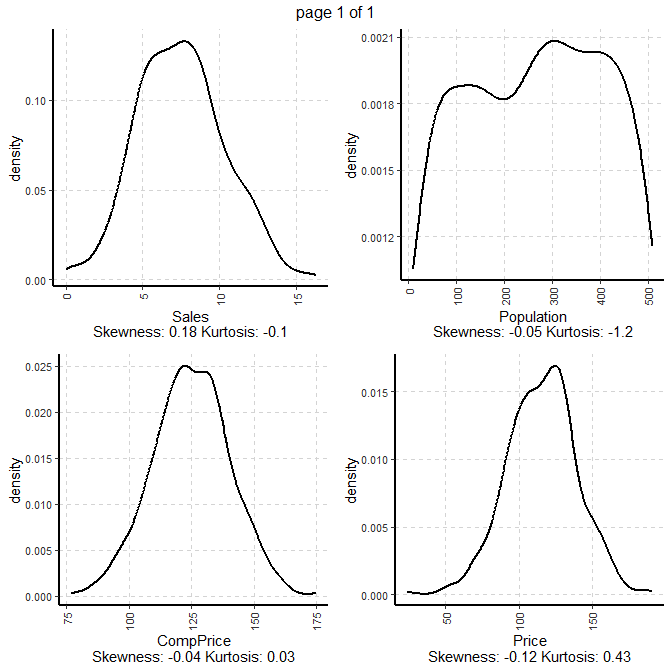

```r
# Note: Variable excluded (if unique value of variable which is less than or eaual to 10 [nlim=10])
plot1 <- ExpNumViz(Carseats,target=NULL,nlim=10,Page=c(2,2),sample=4)
plot1[[1]]
```

#### 3.1.3. Summary of categorical variables

- frequency for all categorical independent variables

```r
ExpCTable(Carseats,Target=NULL,margin=1,clim=10,nlim=3,round=2,bin=NULL,per=T)
```

| Variable | Valid | Frequency | Percent | CumPercent |
| --- | --- | --- | --- | --- |
| ShelveLoc | Bad | 96 | 24.00 | 24.00 |
| ShelveLoc | Good | 85 | 21.25 | 45.25 |
| ShelveLoc | Medium | 219 | 54.75 | 100.00 |
| ShelveLoc | TOTAL | 400 | NA | NA |
| Urban | No | 118 | 29.50 | 29.50 |
| Urban | Yes | 282 | 70.50 | 100.00 |
| Urban | TOTAL | 400 | NA | NA |
| US | No | 142 | 35.50 | 35.50 |
| US | Yes | 258 | 64.50 | 100.00 |
| US | TOTAL | 400 | NA | NA |

> *`NA` is Not Applicable*

#### 3.1.4. Distributions of categorical variables

- Bar plots for all categorical variables

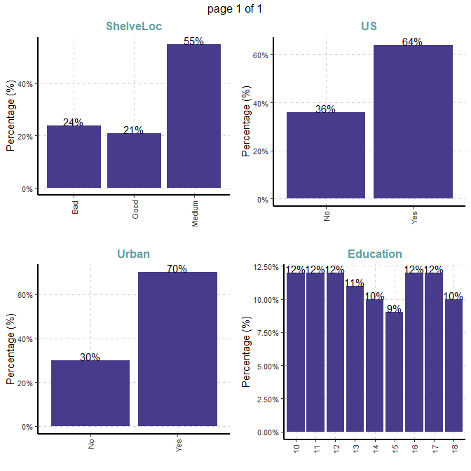

```r
plot2 <- ExpCatViz(Carseats,target=NULL,col ="slateblue4",clim=10,margin=2,Page = c(2,2),sample=4)
plot2[[1]]
```

### 3.2 Example for case 2: Target variable is continuous

#### 3.2.1. Target variable

Summary of continuous dependent variable

1. Variable name - **Price**
2. Variable description - **Price company charges for car seats at each site**

```r
summary(Carseats[,"Price"])
```

```
##      Price
##  Min.   : 24.0
##  1st Qu.:100.0
##  Median :117.0
##  Mean   :115.8
##  3rd Qu.:131.0
##  Max.   :191.0
```

#### 3.2.2 Summary of numerical variables

Summary statistics when dependent variable is continuous **Price**.

```r
ExpNumStat(Carseats,by="A",gp="Price",Qnt=seq(0,1,0.1),MesofShape=1,Outlier=TRUE,round=2)
```

| Vname | Group | Note | TN | nNeg | nZero | nPos | NegInf | PosInf | NA_Value | Per_of_Missing | sum | min | max | mean | median | SD | CV | IQR | 0% | 10% | 20% | 30% | 40% | 50% | 60% | 70% | 80% | 90% | 100% | … |
| --- | --- | --- | --- | --- | --- | --- | --- | --- | --- | --- | --- | --- | --- | --- | --- | --- | --- | --- | --- | --- | --- | --- | --- | --- | --- | --- | --- | --- | --- | --- |
| Advertising | Price | Cor b/w Price | 400 | 0 | 144 | 256 | 0 | 0 | 0 | 0 | 2654.00 | 0 | 29.00 | 6.64 | 5.00 | 6.65 | 1.00 | 12.00 | 0 | 0.00 | 0.00 | 0.00 | 2.00 | 5.00 | 8.40 | 11.00 | 13.00 | 16.0 | 29.00 | … |
| Age | Price | Cor b/w Price | 400 | 0 | 0 | 400 | 0 | 0 | 0 | 0 | 21329.00 | 25 | 80.00 | 53.32 | 54.50 | 16.20 | 0.30 | 26.25 | 25 | 30.00 | 36.00 | 43.00 | 48.60 | 54.50 | 60.00 | 64.00 | 70.00 | 76.0 | 80.00 | … |
| CompPrice | Price | Cor b/w Price | 400 | 0 | 0 | 400 | 0 | 0 | 0 | 0 | 49990.00 | 77 | 175.00 | 124.97 | 125.00 | 15.33 | 0.12 | 20.00 | 77 | 106.00 | 112.80 | 117.00 | 121.00 | 125.00 | 130.00 | 133.00 | 137.20 | 145.0 | 175.00 | … |
| Income | Price | Cor b/w Price | 400 | 0 | 0 | 400 | 0 | 0 | 0 | 0 | 27463.00 | 21 | 120.00 | 68.66 | 69.00 | 27.99 | 0.41 | 48.25 | 21 | 30.00 | 39.00 | 48.00 | 62.00 | 69.00 | 77.00 | 84.60 | 96.20 | 107.0 | 120.00 | … |
| Population | Price | Cor b/w Price | 400 | 0 | 0 | 400 | 0 | 0 | 0 | 0 | 105936.00 | 10 | 509.00 | 264.84 | 272.00 | 147.38 | 0.56 | 259.50 | 10 | 58.90 | 110.40 | 160.00 | 218.60 | 272.00 | 317.80 | 366.00 | 412.20 | 467.0 | 509.00 | … |
| Price | Price | Cor b/w Price | 400 | 0 | 0 | 400 | 0 | 0 | 0 | 0 | 46318.00 | 24 | 191.00 | 115.80 | 117.00 | 23.68 | 0.20 | 31.00 | 24 | 87.00 | 96.80 | 104.00 | 110.00 | 117.00 | 122.00 | 128.30 | 134.00 | 146.0 | 191.00 | … |
| Sales | Price | Cor b/w Price | 400 | 0 | 1 | 399 | 0 | 0 | 0 | 0 | 2998.53 | 0 | 16.27 | 7.50 | 7.49 | 2.82 | 0.38 | 3.93 | 0 | 4.12 | 5.07 | 5.87 | 6.61 | 7.49 | 8.08 | 8.82 | 9.76 | 11.3 | 16.27 | … |

> *If Target variable is continuous, summary statistics will add the correlation column (Correlation between Target variable vs all independent variables)*

#### 3.2.3 Distributions of numerical variables

Graphical representation of all numeric variables

- Scatter plot (Bivariate) - with continuous dependent variable

Scatter plot between all numeric variables and target variable **Price**. This plot help to examine how well a target variable is correlated with dependent variables.

Dependent variable is **Price** (continuous).

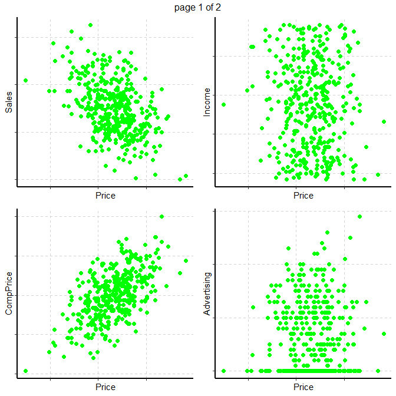

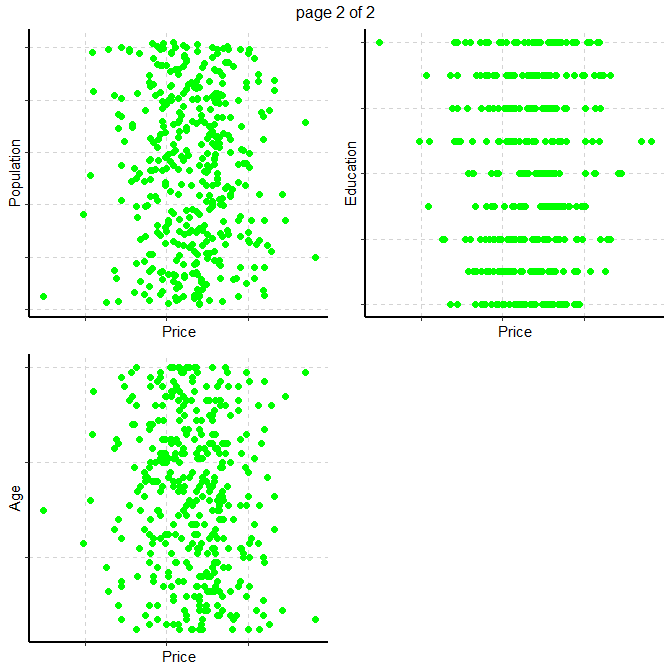

```r
#Note: sample=8 means randomly selected 8 scatter plots
#Note: nlim=4 means included numeric variable with unique value is more than 4
plot3 <- ExpNumViz(Carseats,target="Price",nlim=4,scatter=FALSE,fname=NULL,col="green",Page=c(2,2),sample=8)
plot3[[1]]
```

- Scatter plot (Bivariate) - between all the numerical variables

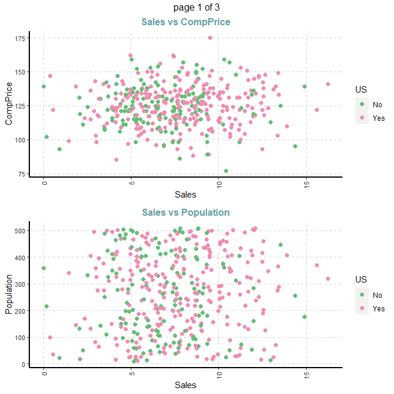

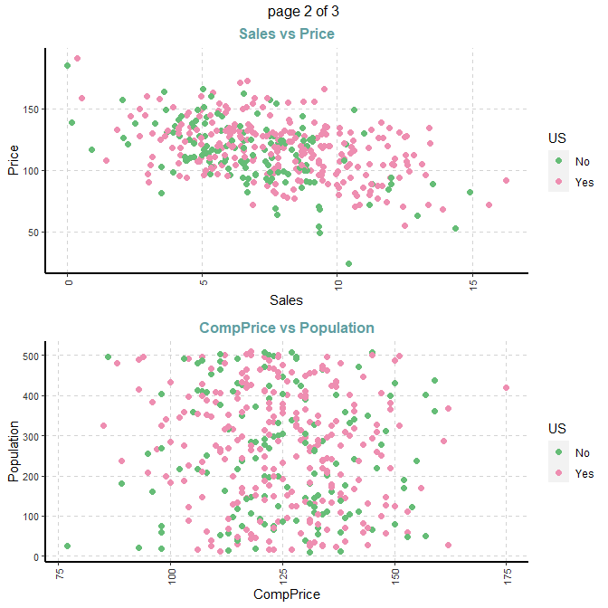

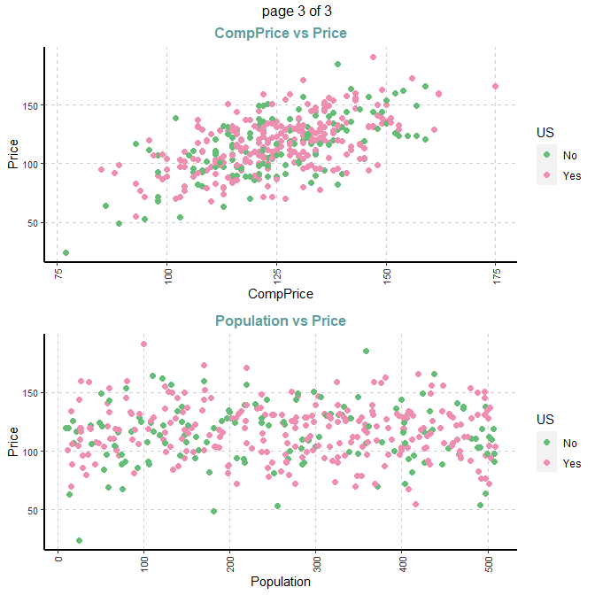

```r
#Note: sample=8 means randomly selected 8 scatter plots
#Note: nlim=4 means included numeric variable with unique value is more than 4
plot31 <- ExpNumViz(Carseats,target="US",nlim=4,scatter=TRUE,fname=NULL,Page=c(2,1),sample=4)
plot31[[1]]
```

#### 3.2.4. Summary of categorical variables

Summary of categorical variables

- frequency for all categorical independent variables by descretized **Price**

```r
##bin=4, descretized 4 categories based on quantiles
ExpCTable(Carseats,Target="Price",margin=1,clim=10,round=2,bin=4,per=F)
```

| VARIABLE | CATEGORY | Price:(23.8,65.8] | Price:(65.8,108] | Price:(108,149] | Price:(149,191] | TOTAL |
| --- | --- | --- | --- | --- | --- | --- |
| ShelveLoc | Bad | 1 | 37 | 51 | 7 | 96 |
| ShelveLoc | Good | 2 | 24 | 50 | 9 | 85 |
| ShelveLoc | Medium | 4 | 78 | 121 | 16 | 219 |
| ShelveLoc | TOTAL | 7 | 139 | 222 | 32 | 400 |
| Urban | No | 1 | 48 | 60 | 9 | 118 |
| Urban | Yes | 6 | 91 | 162 | 23 | 282 |
| Urban | TOTAL | 7 | 139 | 222 | 32 | 400 |
| US | No | 6 | 48 | 79 | 9 | 142 |
| US | Yes | 1 | 91 | 143 | 23 | 258 |
| US | TOTAL | 7 | 139 | 222 | 32 | 400 |

[output cut: 10 more lines]

##### Compute Weighted Summary Statistics for categorical variable

```r
carseat = ISLR::Carseats
## Compute random weight
carseat$wt = stats::runif( nrow(carseat), 0.5, 1.5 )
wt_summary = ExpCTable(carseat,margin=1,clim=10,round=2,bin=4,per=F, weight = "wt")
wt_summary
```

```
##     Variable  Valid Frequency Percent CumPercent
## 1  ShelveLoc    Bad        98   24.08      24.08
## 2  ShelveLoc   Good        84   20.55      44.63
## 3  ShelveLoc Medium       226   55.37     100.00
## 4  ShelveLoc  TOTAL       408      NA         NA
## 5      Urban     No       120   29.45      29.45
## 6      Urban    Yes       288   70.55     100.00
## 7      Urban  TOTAL       408      NA         NA
## 8         US     No       145   35.62      35.62
## 9         US    Yes       262   64.38     100.00
## 10        US  TOTAL       407      NA         NA
## 11 Education     10        51   12.53      12.53
## 12 Education     11        50   12.22      24.75
## 13 Education     12        51   12.48      37.23
## 14 Education     13        43   10.57      47.80
## 15 Education     14        37    9.15      56.95
## 16 Education     15        38    9.26      66.21
## 17 Education     16        47   11.49      77.70
## 18 Education     17        50   12.20      89.90
## 19 Education     18        41   10.11     100.01
## 20 Education  TOTAL       408      NA         NA
```

### 3.3 Example for case 3: Target variable is categorical

#### 3.3.1. Summary of categorical dependent variable

1. Variable name - **Urban**
2. Variable description - **Whether the store is in an urban or rural location**

| Urban | Frequency | Descriptions |
| --- | --- | --- |
| No | 118 | Store location |
| Yes | 282 | Store location |

#### 3.3.2 Summary of numerical variables

Summary of all numeric variables

```r
ExpNumStat(Carseats,by="GA",gp="Urban",Qnt=seq(0,1,0.1),MesofShape=2,Outlier=TRUE,round=2)
```

| Vname | Group | TN | nNeg | nZero | nPos | NegInf | PosInf | NA_Value | Per_of_Missing | sum | min | max | mean | median | SD | CV | IQR | Skewness | Kurtosis | 0% | 10% | 20% | 30% | 40% | 50% | 60% | 70% | 80% | 90% | … |
| --- | --- | --- | --- | --- | --- | --- | --- | --- | --- | --- | --- | --- | --- | --- | --- | --- | --- | --- | --- | --- | --- | --- | --- | --- | --- | --- | --- | --- | --- | --- |
| Advertising | Urban:All | 400 | 0 | 144 | 256 | 0 | 0 | 0 | 0 | 2654.00 | 0.00 | 29.00 | 6.64 | 5.00 | 6.65 | 1.00 | 12.00 | 0.64 | -0.55 | 0.00 | 0.00 | 0.00 | 0.00 | 2.00 | 5.00 | 8.40 | 11.00 | 13.00 | 16.00 | … |
| Advertising | Urban:Yes | 282 | 0 | 94 | 188 | 0 | 0 | 0 | 0 | 1922.00 | 0.00 | 29.00 | 6.82 | 5.00 | 6.73 | 0.99 | 12.00 | 0.66 | -0.49 | 0.00 | 0.00 | 0.00 | 0.00 | 3.00 | 5.00 | 8.00 | 11.00 | 13.00 | 16.00 | … |
| Advertising | Urban:No | 118 | 0 | 50 | 68 | 0 | 0 | 0 | 0 | 732.00 | 0.00 | 24.00 | 6.20 | 5.00 | 6.47 | 1.04 | 11.00 | 0.56 | -0.80 | 0.00 | 0.00 | 0.00 | 0.00 | 0.00 | 5.00 | 9.00 | 10.90 | 12.00 | 14.00 | … |
| Age | Urban:All | 400 | 0 | 0 | 400 | 0 | 0 | 0 | 0 | 21329.00 | 25.00 | 80.00 | 53.32 | 54.50 | 16.20 | 0.30 | 26.25 | -0.08 | -1.14 | 25.00 | 30.00 | 36.00 | 43.00 | 48.60 | 54.50 | 60.00 | 64.00 | 70.00 | 76.00 | … |
| Age | Urban:Yes | 282 | 0 | 0 | 282 | 0 | 0 | 0 | 0 | 15121.00 | 25.00 | 80.00 | 53.62 | 55.00 | 15.98 | 0.30 | 24.75 | -0.10 | -1.10 | 25.00 | 32.00 | 37.00 | 43.00 | 50.00 | 55.00 | 61.00 | 64.00 | 69.00 | 75.00 | … |
| Age | Urban:No | 118 | 0 | 0 | 118 | 0 | 0 | 0 | 0 | 6208.00 | 25.00 | 80.00 | 52.61 | 53.50 | 16.76 | 0.32 | 28.00 | -0.01 | -1.20 | 25.00 | 29.00 | 36.00 | 41.00 | 47.00 | 53.50 | 57.00 | 63.90 | 71.60 | 76.00 | … |
| CompPrice | Urban:All | 400 | 0 | 0 | 400 | 0 | 0 | 0 | 0 | 49990.00 | 77.00 | 175.00 | 124.97 | 125.00 | 15.33 | 0.12 | 20.00 | -0.04 | 0.03 | 77.00 | 106.00 | 112.80 | 117.00 | 121.00 | 125.00 | 130.00 | 133.00 | 137.20 | 145.00 | … |
| CompPrice | Urban:Yes | 282 | 0 | 0 | 282 | 0 | 0 | 0 | 0 | 35429.00 | 77.00 | 175.00 | 125.63 | 125.00 | 15.70 | 0.12 | 20.00 | -0.04 | 0.14 | 77.00 | 106.00 | 113.00 | 117.00 | 122.00 | 125.00 | 130.00 | 133.70 | 138.00 | 145.90 | … |
| CompPrice | Urban:No | 118 | 0 | 0 | 118 | 0 | 0 | 0 | 0 | 14561.00 | 88.00 | 154.00 | 123.40 | 123.00 | 14.36 | 0.12 | 20.25 | -0.10 | -0.47 | 88.00 | 106.00 | 111.00 | 115.10 | 120.80 | 123.00 | 128.00 | 132.00 | 135.00 | 142.30 | … |
| Income | Urban:All | 400 | 0 | 0 | 400 | 0 | 0 | 0 | 0 | 27463.00 | 21.00 | 120.00 | 68.66 | 69.00 | 27.99 | 0.41 | 48.25 | 0.05 | -1.09 | 21.00 | 30.00 | 39.00 | 48.00 | 62.00 | 69.00 | 77.00 | 84.60 | 96.20 | 107.00 | … |

[output cut: 11 more lines]

#### 3.3.3 Distributions of Numerical variables

- Box plots for all numerical variables vs categorical dependent variable - Bivariate comparision only with categories

Boxplot for all the numeric attributes by each category of **Urban**

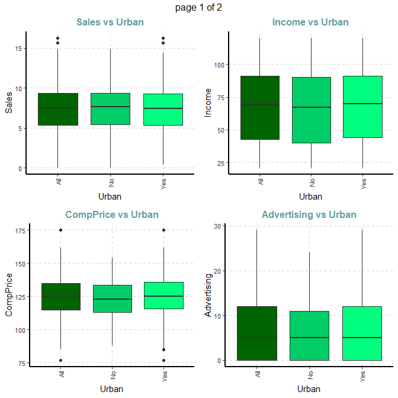

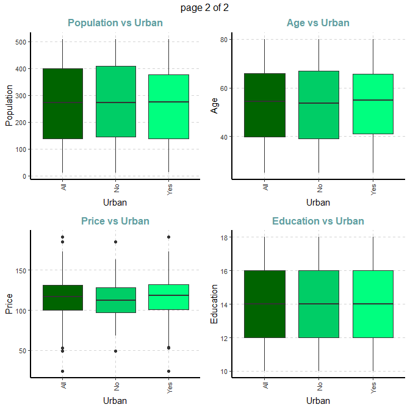

```r
plot4 <- ExpNumViz(Carseats,target="Urban",type=1,nlim=3,fname=NULL,col=c("darkgreen","springgreen3","springgreen1"),Page=c(2,2),sample=8)
plot4[[1]]
```

#### 3.3.4 Summary of categorical variables

**Cross tabulation with target variable**

- Custom tables between all categorical independent variables and target variable **Urban**

```r
ExpCTable(Carseats,Target="Urban",margin=1,clim=10,nlim=3,round=2,bin=NULL,per=F)
```

| VARIABLE | CATEGORY | Urban:No | Urban:Yes | TOTAL |
| --- | --- | --- | --- | --- |
| ShelveLoc | Bad | 22 | 74 | 96 |
| ShelveLoc | Good | 28 | 57 | 85 |
| ShelveLoc | Medium | 68 | 151 | 219 |
| ShelveLoc | TOTAL | 118 | 282 | 400 |
| US | No | 46 | 96 | 142 |
| US | Yes | 72 | 186 | 258 |
| US | TOTAL | 118 | 282 | 400 |

**Information Value**

```r
ExpCatStat(Carseats,Target="Urban",result = "IV",clim=10,nlim=5,bins=10,Pclass="Yes",plot=FALSE,top=20,Round=2)
```

| Variable | Class | Out_1 | Out_0 | TOTAL | Per_1 | Per_0 | Odds | WOE | IV | Ref_1 | Ref_0 | Target |
| --- | --- | --- | --- | --- | --- | --- | --- | --- | --- | --- | --- | --- |
| ShelveLoc.1 | Bad | 74 | 22 | 96 | 0.26 | 0.19 | 1.55 | 0.31 | 0.02 | Yes | No | Urban |
| ShelveLoc.2 | Good | 57 | 28 | 85 | 0.20 | 0.24 | 0.81 | -0.19 | 0.01 | Yes | No | Urban |
| ShelveLoc.3 | Medium | 151 | 68 | 219 | 0.54 | 0.58 | 0.85 | -0.07 | 0.00 | Yes | No | Urban |
| US.1 | No | 96 | 46 | 142 | 0.34 | 0.39 | 0.81 | -0.14 | 0.01 | Yes | No | Urban |
| US.2 | Yes | 186 | 72 | 258 | 0.66 | 0.61 | 1.24 | 0.08 | 0.00 | Yes | No | Urban |
| Sales.1 | [0,4.11] | 29 | 11 | 40 | 0.10 | 0.09 | 1.11 | 0.10 | 0.00 | Yes | No | Urban |
| Sales.2 | (4.11,5.05] | 29 | 11 | 40 | 0.10 | 0.09 | 1.11 | 0.10 | 0.00 | Yes | No | Urban |
| Sales.3 | (5.05,5.86] | 26 | 14 | 40 | 0.09 | 0.12 | 0.75 | -0.29 | 0.01 | Yes | No | Urban |
| Sales.4 | (5.86,6.59] | 30 | 10 | 40 | 0.11 | 0.08 | 1.29 | 0.32 | 0.01 | Yes | No | Urban |
| Sales.5 | (6.59,7.49] | 32 | 9 | 41 | 0.11 | 0.08 | 1.55 | 0.32 | 0.01 | Yes | No | Urban |
| Sales.6 | (7.49,8.07] | 30 | 9 | 39 | 0.11 | 0.08 | 1.44 | 0.32 | 0.01 | Yes | No | Urban |
| Sales.7 | (8.07,8.8] | 24 | 16 | 40 | 0.09 | 0.14 | 0.59 | -0.45 | 0.02 | Yes | No | Urban |
| Sales.8 | (8.8,9.71] | 26 | 14 | 40 | 0.09 | 0.12 | 0.75 | -0.29 | 0.01 | Yes | No | Urban |
| Sales.9 | (9.71,11.28] | 26 | 14 | 40 | 0.09 | 0.12 | 0.75 | -0.29 | 0.01 | Yes | No | Urban |
| Sales.10 | (11.28,16.27] | 30 | 10 | 40 | 0.11 | 0.08 | 1.29 | 0.32 | 0.01 | Yes | No | Urban |

**Statistical test**

```r
et4 <- ExpCatStat(Carseats,Target="Urban",result = "Stat",clim=10,nlim=5,bins=10,Pclass="Yes",plot=FALSE,top=20,Round=2)
```

[output not shown]

**Variable importance based on Information value**

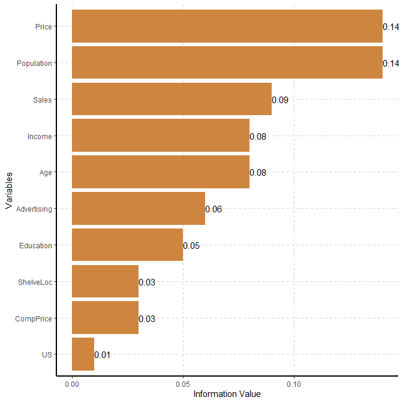

```r
varimp <- ExpCatStat(Carseats,Target="Urban",result = "Stat",clim=10,nlim=5,bins=10,Pclass="Yes",plot=TRUE,top=10,Round=2)
```

#### 3.3.5. Distributions of categorical variables

Stacked bar plot with vertical or horizontal bars for all categorical variables

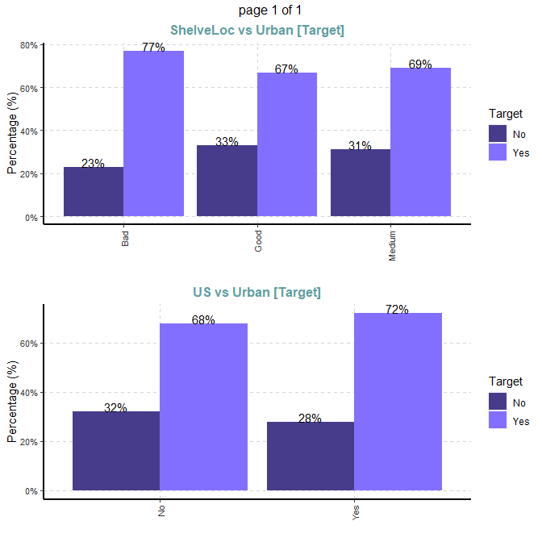

```r
plot5 <- ExpCatViz(Carseats,target="Urban",fname=NULL,clim=5,col=c("slateblue4","slateblue1"),margin=2,Page = c(2,1),sample=2)
plot5[[1]]
```

## 4. Quantile-quantile plot for numeric variables

Function definition:

```
ExpOutQQ (data,nlim=3,fname=NULL,Page=NULL,sample=NULL)
data    : Input dataframe or data.table
nlim    : numeric variable limit
fname   : output file name (Output will be in PDF format)
Page    : output pattern. if Page=c(3,2), It will generate 6 plots with 3 rows and 2 columns
sample  : random number of plots
```

Carseats data from ISLR package:

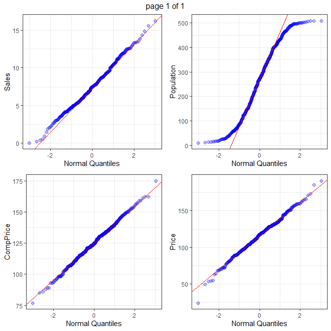

```r
options(width = 150)
CData = ISLR::Carseats
qqp <- ExpOutQQ(CData,nlim=10,fname=NULL,Page=c(2,2),sample=4)
qqp[[1]]
```

## 5. Parallel Co-ordinate plots

Function definition:

```
ExpParcoord (data,Group=NULL,Stsize=NULL,Nvar=NULL,Cvar=NULL,scale=NULL)
data    : Input dataframe or data.table
Group   : stratification variables
Stsize  : vector of startum sample sizes
Nvar    : vector of numerice variables, default it will consider all the numeric variable from data
Cvar    : vector of categorical variables, default it will consider all the categorical variable
scale   : scale the variables in the parallel coordinate plot[Default normailized with minimum of the variable is zero and maximum of the variable is one]
```

### 5.1 Defualt ExpParcoord funciton

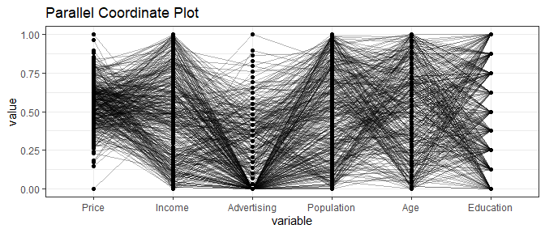

```r
ExpParcoord(CData,Group=NULL,Stsize=NULL,Nvar=c("Price","Income","Advertising","Population","Age","Education"))
```

### 5.2 With Stratified rows and selected columns only

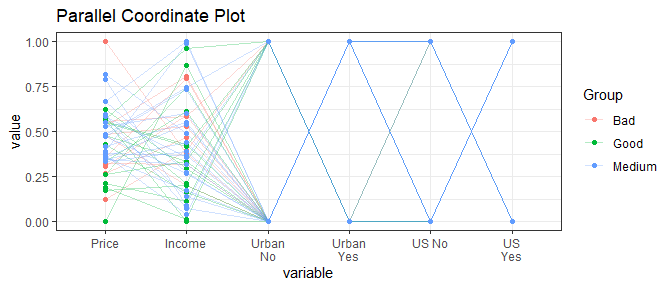

```r
ExpParcoord(CData,Group="ShelveLoc",Stsize=c(10,15,20),Nvar=c("Price","Income"),Cvar=c("Urban","US"))
```

### 5.3 Without stratification

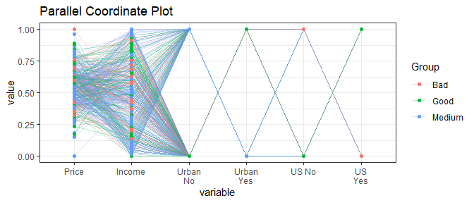

```r
ExpParcoord(CData,Group="ShelveLoc",Nvar=c("Price","Income"),Cvar=c("Urban","US"),scale=NULL)
```

### 5.4 Scale change

`std: univariately, subtract mean and divide by standard deviation`

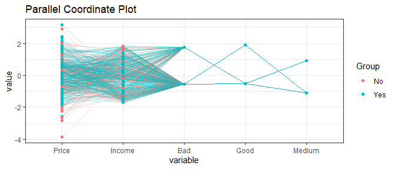

```r
ExpParcoord(CData,Group="US",Nvar=c("Price","Income"),Cvar=c("ShelveLoc"),scale="std")
```

### 5.5 Selected numeric variables

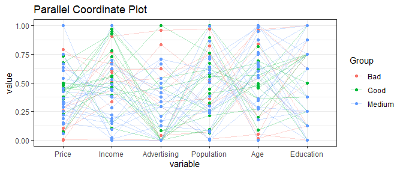

```r
ExpParcoord(CData,Group="ShelveLoc",Stsize=c(10,15,20),Nvar=c("Price","Income","Advertising","Population","Age","Education"))
```

### 5.6 Selected categorical variables

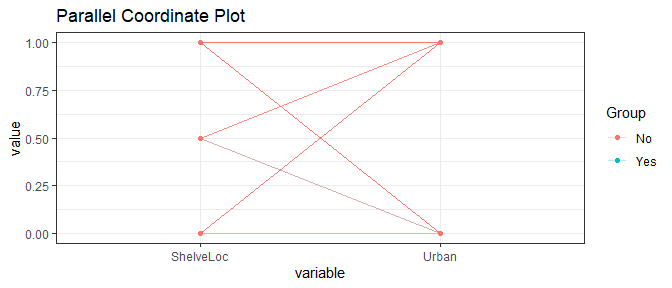

```r
ExpParcoord(CData,Group="US",Stsize=c(15,50),Cvar=c("ShelveLoc","Urban"))
```

## 6. Customized Summary Statistics

Used ‘data.table’ package functions

Function definition:

```
ExpCustomStat(data,Cvar=NULL,Nvar=NULL,stat=NULL,gpby=TRUE,filt=NULL,dcast=FALSE)
```

**ExpCustomStat examples**

```r
ExpCustomStat(Carseats,Cvar="Urban",Nvar=c("Age","Price"),stat=c("mean","count"),gpby=TRUE,dcast=F)
```

| Urban | Attribute | mean | count |
| --- | --- | --- | --- |
| Yes | Age | 53.62057 | 282 |
| No | Age | 52.61017 | 118 |
| Yes | Price | 116.51418 | 282 |
| No | Price | 114.07627 | 118 |

```r
ExpCustomStat(Carseats,Cvar="Urban",Nvar=c("Age","Price"),stat=c("mean","count"),gpby=TRUE,dcast=T)
```

| Attribute | mean_No | mean_Yes | count_No | count_Yes |
| --- | --- | --- | --- | --- |
| Age | 52.61017 | 53.62057 | 118 | 282 |
| Price | 114.07627 | 116.51418 | 118 | 282 |

```r
ExpCustomStat(Carseats,Cvar=c("Urban","ShelveLoc"),Nvar=c("Age","Price","Advertising","Sales"),stat=c("mean"),gpby=FALSE,dcast=T)
```

| Attribute | ShelveLoc_Bad | ShelveLoc_Good | ShelveLoc_Medium | Urban_No | Urban_Yes |
| --- | --- | --- | --- | --- | --- |
| Advertising | 6.218750 | 7.352941 | 6.538813 | 6.203390 | 6.815603 |
| Age | 52.052083 | 52.611765 | 54.155251 | 52.610169 | 53.620567 |
| Price | 114.270833 | 117.882353 | 115.652968 | 114.076271 | 116.514184 |
| Sales | 5.522917 | 10.214000 | 7.306575 | 7.563559 | 7.468191 |

## 7. Univariate outlier analysis

In statistics, an outlier is a data point that differs significantly from other observations. An outlier may be due to variability in the measurement or it may indicate experimental error; the latter are sometimes excluded from the data set.An outlier can cause serious problems in statistical analyses.

Function `ExpOutliers` can run univariate outlier analysis based on boxplot or SD method. The function returns the summary of oultlier for selected numeric features and adding new features if there are any outlers

Identifying outliers: There are several methods we can use to identify outliers. In `ExpOutliers` used two methods (1) Boxplot and (2) Standard Deviation

### 7.1 Identifying outliers using Boxplot method

```r
ExpOutliers(Carseats, varlist = c("Sales","CompPrice","Income"), method = "boxplot",  treatment = "mean", capping = c(0.1, 0.9))
```

**Summary**

| Category | Sales | CompPrice | Income |
| --- | --- | --- | --- |
| Lower cap : 0.1 | 4.119 | 106 | 30 |
| Upper cap : 0.9 | 11.3 | 145 | 107 |
| Lower bound | -0.5 | 85 | -29.62 |
| Upper bound | 15.21 | 165 | 163.38 |
| Num of outliers | 2 | 2 | 0 |
| Lower outlier case |  | 43 |  |
| Upper outlier case | 317,377 | 311 |  |
| Mean before | 7.5 | 124.97 | 68.66 |
| Mean after | 7.45 | 124.97 | 68.66 |
| Median before | 7.49 | 125 | 69 |
| Median after | 7.47 | 125 | 69 |

**Output data head view**

| Sales | CompPrice | Income | Advertising | Population | Price | ShelveLoc | Age | Education | Urban | US | out_cap_Sales | out_cap_CompPrice | out_imp_Sales | out_imp_CompPrice |
| --- | --- | --- | --- | --- | --- | --- | --- | --- | --- | --- | --- | --- | --- | --- |
| 9.50 | 138 | 73 | 11 | 276 | 120 | Bad | 42 | 17 | Yes | Yes | 9.50 | 138 | 9.50 | 138 |
| 11.22 | 111 | 48 | 16 | 260 | 83 | Good | 65 | 10 | Yes | Yes | 11.22 | 111 | 11.22 | 111 |
| 10.06 | 113 | 35 | 10 | 269 | 80 | Medium | 59 | 12 | Yes | Yes | 10.06 | 113 | 10.06 | 113 |
| 7.40 | 117 | 100 | 4 | 466 | 97 | Medium | 55 | 14 | Yes | Yes | 7.40 | 117 | 7.40 | 117 |
| 4.15 | 141 | 64 | 3 | 340 | 128 | Bad | 38 | 13 | Yes | No | 4.15 | 141 | 4.15 | 141 |
| 10.81 | 124 | 113 | 13 | 501 | 72 | Bad | 78 | 16 | No | Yes | 10.81 | 124 | 10.81 | 124 |

### 7.2 Identifying outliers using 3 Standard Deviation method

```r
ExpOutliers(Carseats, varlist = c("Sales","CompPrice","Income"), method = "3xStDev",  treatment = "medain", capping = c(0.1, 0.9))
```

**Summary**

| Category | Sales | CompPrice | Income |
| --- | --- | --- | --- |
| Lower cap : 0.1 | 4.119 | 106 | 30 |
| Upper cap : 0.9 | 11.3 | 145 | 107 |
| Lower bound | -0.98 | 78.97 | -15.3 |
| Upper bound | 15.97 | 170.98 | 152.62 |
| Num of outliers | 1 | 2 | 0 |
| Lower outlier case |  | 43 |  |
| Upper outlier case | 377 | 311 |  |
| Mean before | 7.5 | 124.97 | 68.66 |
| Mean after | 7.47 | 124.97 | 68.66 |
| Median before | 7.49 | 125 | 69 |
| Median after | 7.49 | 125 | 69 |

**Output data head view**

| Sales | CompPrice | Income | Advertising | Population | Price | ShelveLoc | Age | Education | Urban | US | out_cap_Sales | out_cap_CompPrice | out_imp_Sales | out_imp_CompPrice |
| --- | --- | --- | --- | --- | --- | --- | --- | --- | --- | --- | --- | --- | --- | --- |
| 9.50 | 138 | 73 | 11 | 276 | 120 | Bad | 42 | 17 | Yes | Yes | 9.50 | 138 | 9.50 | 138 |
| 11.22 | 111 | 48 | 16 | 260 | 83 | Good | 65 | 10 | Yes | Yes | 11.22 | 111 | 11.22 | 111 |
| 10.06 | 113 | 35 | 10 | 269 | 80 | Medium | 59 | 12 | Yes | Yes | 10.06 | 113 | 10.06 | 113 |
| 7.40 | 117 | 100 | 4 | 466 | 97 | Medium | 55 | 14 | Yes | Yes | 7.40 | 117 | 7.40 | 117 |
| 4.15 | 141 | 64 | 3 | 340 | 128 | Bad | 38 | 13 | Yes | No | 4.15 | 141 | 4.15 | 141 |
| 10.81 | 124 | 113 | 13 | 501 | 72 | Bad | 78 | 16 | No | Yes | 10.81 | 124 | 10.81 | 124 |